# Лабораторная работа 8. Деревья классификации

Natalia Korskova

2016-05-02

### Вариант 8. Оливковые масла

Считываем данные и дорабатываем переменную с именем согласно предыдущей работе:

```r
olive <- read.table("olive.txt", header = TRUE, sep = c(","))
olive$name <- gsub('[0-9]+[.]', '', olive$name)
summary(olive)
```

```
##      name               region           area        palmitic
##  Length:572         Min.   :1.000   Min.   :1.0   Min.   : 610
##  Class :character   1st Qu.:1.000   1st Qu.:3.0   1st Qu.:1095
##  Mode  :character   Median :1.000   Median :3.0   Median :1201
##                     Mean   :1.699   Mean   :4.6   Mean   :1232
##                     3rd Qu.:3.000   3rd Qu.:7.0   3rd Qu.:1360
##                     Max.   :3.000   Max.   :9.0   Max.   :1753
##   palmitoleic        stearic          oleic         linoleic
##  Min.   : 15.00   Min.   :152.0   Min.   :6300   Min.   : 448.0
##  1st Qu.: 87.75   1st Qu.:205.0   1st Qu.:7000   1st Qu.: 770.8
##  Median :110.00   Median :223.0   Median :7302   Median :1030.0
##  Mean   :126.09   Mean   :228.9   Mean   :7312   Mean   : 980.5
##  3rd Qu.:169.25   3rd Qu.:249.0   3rd Qu.:7680   3rd Qu.:1180.8
##  Max.   :280.00   Max.   :375.0   Max.   :8410   Max.   :1470.0
##    linolenic       arachidic       eicosenoic
##  Min.   : 0.00   Min.   :  0.0   Min.   : 1.00
##  1st Qu.:26.00   1st Qu.: 50.0   1st Qu.: 2.00
##  Median :33.00   Median : 61.0   Median :17.00
##  Mean   :31.89   Mean   : 58.1   Mean   :16.28
##  3rd Qu.:40.25   3rd Qu.: 70.0   3rd Qu.:28.00
##  Max.   :74.00   Max.   :105.0   Max.   :58.00
```

Программа-минимум состоит в классификации оливковых масел для трёх регионов (переменная region) на основании жирных кислот (столбцы с 4 по 11).

Разобьём выборку на обучающее и тестовое множество в пропорции 2:1, оставив столбцы о содержании жирных кислот и регион:

```r
set.seed(1234)
test_num <- sample(1:nrow(olive), 191, replace = FALSE)
olive_train <- olive[-test_num, c(2, 4:11)]
olive_test <- olive[test_num, c(2, 4:11)]
```

Результат работы деревьев классификации для обучающем множестве:

```r
library(rpart)
res <- rpart(region ~., data = olive_train, method="class", control = rpart.control(minsplit=10, minbucket=5, maxdepth=6))
res
```

```
## n= 381
##
## node), split, n, loss, yval, (yprob)
##       * denotes terminal node
##
## 1) root 381 169 1 (0.5564304 0.1732283 0.2703412)
##   2) eicosenoic>=6.5 212   0 1 (1.0000000 0.0000000 0.0000000) *
##   3) eicosenoic< 6.5 169  66 3 (0.0000000 0.3905325 0.6094675)
##     6) oleic< 7438.5 66   0 2 (0.0000000 1.0000000 0.0000000) *
##     7) oleic>=7438.5 103   0 3 (0.0000000 0.0000000 1.0000000) *
```

Для решающих деревьев оказались достаточными всего две переменные: кислоты eicosenoic и oleic.

Результат в виде дерева:

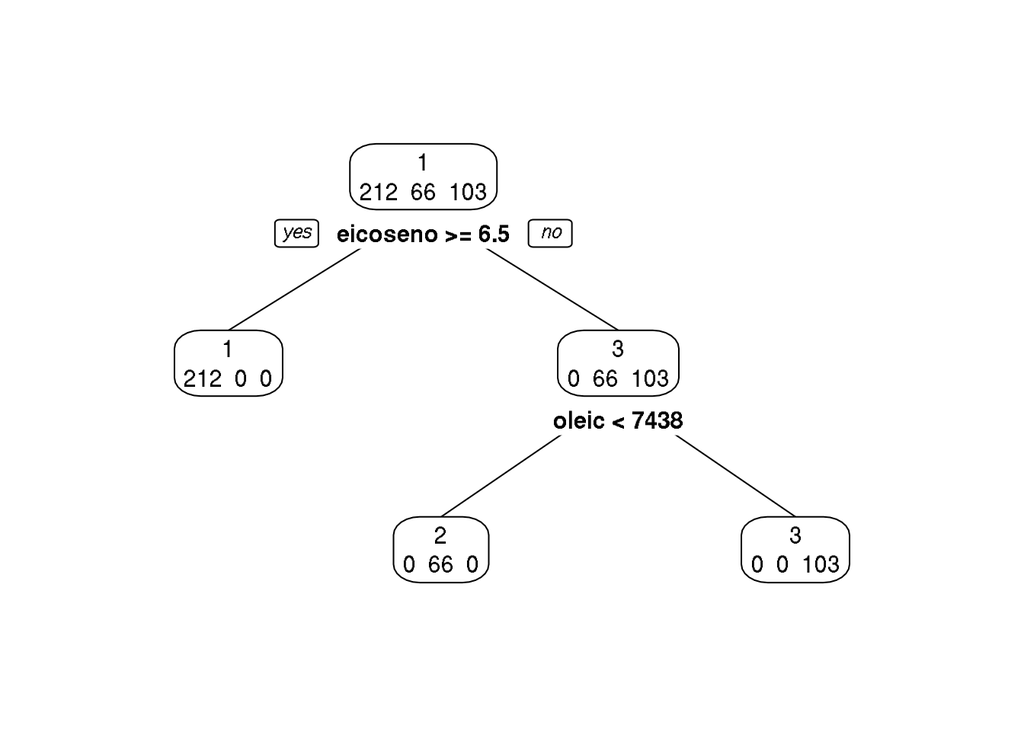

```r
library(rpart.plot)
rpart.plot(res, type = 2, extra = 1)
```

Безошибочный результат. Если значение eicosenoic >= 6.5, то масло из региона 1, если значение eicosenoic < 6.5 и значение oleic < 7438, то масло из региона 2, а если значение eicosenoic < 6.5 и значение oleic >= 7438, то масло из региона 3.

Посмотрим на результат на тестовом множестве:

```r
pred <- predict(res, olive_test, type="class")
table(olive_test$region, pred)
```

```
##    pred
##       1   2   3
##   1 111   0   0
##   2   0  31   1
##   3   0   2  46
```

На тестовом множестве 3 ошибки. Это больше, чем 0 ошибок на обучающем множестве, но дерево имеет всего 3 листа – обрезать нечего для 3 регионов.

Выделим область Умбрии в отдельный регион, как это было сделано в прошлой работе:

```r
olive_1 <- olive
olive_1$region[olive_1$name == "Umbria"] <- 4
olive_1_train <- olive_1[-test_num, c(2, 4:11)]
olive_1_test <- olive_1[test_num, c(2, 4:11)]
```

Работа деревьев классификации:

```r
res_1 <- rpart(region ~., data = olive_1_train, method="class", control = rpart.control(minsplit=10, minbucket=5, maxdepth=6))
res_1
```

```
## n= 381
##
## node), split, n, loss, yval, (yprob)
##       * denotes terminal node
##
##  1) root 381 169 1 (0.55643045 0.17322835 0.19160105 0.07874016)
##    2) eicosenoic>=6.5 212   0 1 (1.00000000 0.00000000 0.00000000 0.00000000) *
##    3) eicosenoic< 6.5 169  96 3 (0.00000000 0.39053254 0.43195266 0.17751479)
##      6) oleic< 7438.5 66   0 2 (0.00000000 1.00000000 0.00000000 0.00000000) *
##      7) oleic>=7438.5 103  30 3 (0.00000000 0.00000000 0.70873786 0.29126214)
##       14) oleic< 7895 70   0 3 (0.00000000 0.00000000 1.00000000 0.00000000) *
##       15) oleic>=7895 33   3 4 (0.00000000 0.00000000 0.09090909 0.90909091) *
```

Графическое изображение дерева:

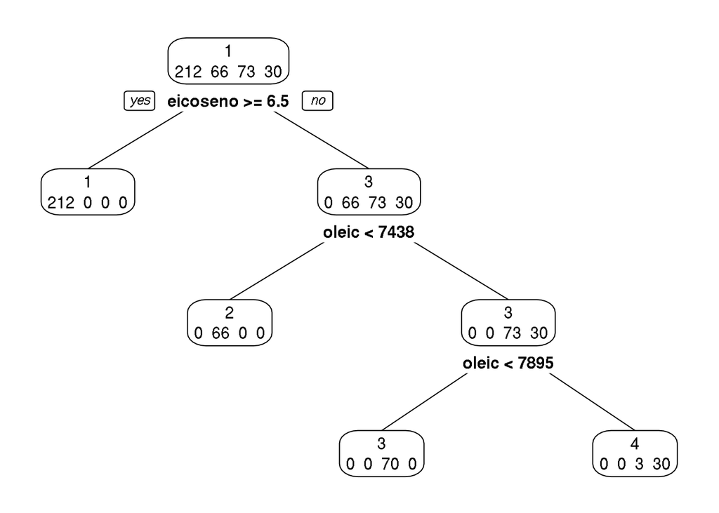

```r
rpart.plot(res_1, type = 2, extra = 1)
```

```r
unique(olive$name[olive$region == 3])
```

```
## [1] "Umbria"       "East-Liguria" "West-Liguria"
```

Работа на тестовом множестве:

```r
pred_1 <- predict(res_1, olive_1_test, type="class")
table(olive_1_test$region, pred_1)
```

```
##    pred_1
##       1   2   3   4
##   1 111   0   0   0
##   2   0  31   1   0
##   3   0   2  23   2
##   4   0   0   0  21
```

Получилось 5 ошибок, результат сравним с работой на обучающей выборке и потому считается приемлемым.